# Risk Factor Analysis

## Outcome Variable

**Outcome Variable:** y_rate_len

## Predictor Variables

**Intervention Variable:** nhh

**Adjustment Set:**

- arm
- W_mage
- meducyrs
- feducyrs
- W_mhtcm
- W_mwtkg
- W_mbmi
- W_nrooms
- trth2o
- cleanck
- impfloor
- impsan
- safeh20
- delta_W_mage
- delta_meducyrs
- delta_feducyrs
- delta_W_mhtcm
- delta_W_mwtkg
- delta_W_mbmi
- delta_W_nrooms
- delta_trth2o
- delta_cleanck
- delta_impfloor
- delta_impsan
- delta_safeh20

## Stratifying Variables

The analysis was stratified on these variable(s):

- agecat
- studyid
- country

## Data Summary

| agecat | studyid | country | nhh | n_cell | n |
| --- | --- | --- | --- | --- | --- |
| 0-3 months | IRC | INDIA | 3 or less | 53 | 377 |
| 0-3 months | IRC | INDIA | 4-5 | 146 | 377 |
| 0-3 months | IRC | INDIA | 6-7 | 99 | 377 |
| 0-3 months | IRC | INDIA | 8+ | 79 | 377 |
| 0-3 months | NIH-Birth | BANGLADESH | 3 or less | 101 | 566 |
| 0-3 months | NIH-Birth | BANGLADESH | 4-5 | 239 | 566 |
| 0-3 months | NIH-Birth | BANGLADESH | 6-7 | 132 | 566 |
| 0-3 months | NIH-Birth | BANGLADESH | 8+ | 94 | 566 |
| 0-3 months | NIH-Crypto | BANGLADESH | 3 or less | 108 | 721 |
| 0-3 months | NIH-Crypto | BANGLADESH | 4-5 | 324 | 721 |
| 0-3 months | NIH-Crypto | BANGLADESH | 6-7 | 169 | 721 |
| 0-3 months | NIH-Crypto | BANGLADESH | 8+ | 120 | 721 |
| 0-3 months | PROVIDE | BANGLADESH | 3 or less | 123 | 640 |
| 0-3 months | PROVIDE | BANGLADESH | 4-5 | 296 | 640 |
| 0-3 months | PROVIDE | BANGLADESH | 6-7 | 136 | 640 |
| 0-3 months | PROVIDE | BANGLADESH | 8+ | 85 | 640 |
| 3-6 months | IRC | INDIA | 3 or less | 57 | 397 |
| 3-6 months | IRC | INDIA | 4-5 | 154 | 397 |
| 3-6 months | IRC | INDIA | 6-7 | 103 | 397 |
| 3-6 months | IRC | INDIA | 8+ | 83 | 397 |
| 3-6 months | NIH-Birth | BANGLADESH | 3 or less | 89 | 523 |
| 3-6 months | NIH-Birth | BANGLADESH | 4-5 | 223 | 523 |
| 3-6 months | NIH-Birth | BANGLADESH | 6-7 | 126 | 523 |
| 3-6 months | NIH-Birth | BANGLADESH | 8+ | 85 | 523 |
| 3-6 months | NIH-Crypto | BANGLADESH | 3 or less | 101 | 695 |
| 3-6 months | NIH-Crypto | BANGLADESH | 4-5 | 316 | 695 |
| 3-6 months | NIH-Crypto | BANGLADESH | 6-7 | 163 | 695 |
| 3-6 months | NIH-Crypto | BANGLADESH | 8+ | 115 | 695 |
| 3-6 months | PROVIDE | BANGLADESH | 3 or less | 104 | 598 |
| 3-6 months | PROVIDE | BANGLADESH | 4-5 | 285 | 598 |

[output cut: 138 more lines]

The following strata were considered:

- agecat: 0-3 months, studyid: IRC, country: INDIA
- agecat: 0-3 months, studyid: NIH-Birth, country: BANGLADESH
- agecat: 0-3 months, studyid: NIH-Crypto, country: BANGLADESH
- agecat: 0-3 months, studyid: PROVIDE, country: BANGLADESH
- agecat: 12-15 months, studyid: IRC, country: INDIA
- agecat: 12-15 months, studyid: LCNI-5, country: MALAWI
- agecat: 12-15 months, studyid: NIH-Birth, country: BANGLADESH
- agecat: 12-15 months, studyid: NIH-Crypto, country: BANGLADESH
- agecat: 12-15 months, studyid: PROVIDE, country: BANGLADESH
- agecat: 12-15 months, studyid: SAS-FoodSuppl, country: INDIA
- agecat: 15-18 months, studyid: IRC, country: INDIA
- agecat: 15-18 months, studyid: LCNI-5, country: MALAWI
- agecat: 15-18 months, studyid: NIH-Birth, country: BANGLADESH
- agecat: 15-18 months, studyid: NIH-Crypto, country: BANGLADESH
- agecat: 15-18 months, studyid: PROVIDE, country: BANGLADESH
- agecat: 15-18 months, studyid: SAS-FoodSuppl, country: INDIA
- agecat: 18-21 months, studyid: IRC, country: INDIA
- agecat: 18-21 months, studyid: LCNI-5, country: MALAWI
- agecat: 18-21 months, studyid: NIH-Birth, country: BANGLADESH
- agecat: 18-21 months, studyid: NIH-Crypto, country: BANGLADESH
- agecat: 18-21 months, studyid: PROVIDE, country: BANGLADESH
- agecat: 21-24 months, studyid: IRC, country: INDIA
- agecat: 21-24 months, studyid: LCNI-5, country: MALAWI
- agecat: 21-24 months, studyid: NIH-Birth, country: BANGLADESH
- agecat: 21-24 months, studyid: NIH-Crypto, country: BANGLADESH
- agecat: 21-24 months, studyid: PROVIDE, country: BANGLADESH
- agecat: 3-6 months, studyid: IRC, country: INDIA
- agecat: 3-6 months, studyid: NIH-Birth, country: BANGLADESH
- agecat: 3-6 months, studyid: NIH-Crypto, country: BANGLADESH
- agecat: 3-6 months, studyid: PROVIDE, country: BANGLADESH
- agecat: 6-9 months, studyid: IRC, country: INDIA
- agecat: 6-9 months, studyid: LCNI-5, country: MALAWI
- agecat: 6-9 months, studyid: NIH-Birth, country: BANGLADESH
- agecat: 6-9 months, studyid: NIH-Crypto, country: BANGLADESH
- agecat: 6-9 months, studyid: PROVIDE, country: BANGLADESH
- agecat: 6-9 months, studyid: SAS-FoodSuppl, country: INDIA
- agecat: 9-12 months, studyid: IRC, country: INDIA
- agecat: 9-12 months, studyid: LCNI-5, country: MALAWI
- agecat: 9-12 months, studyid: NIH-Birth, country: BANGLADESH
- agecat: 9-12 months, studyid: NIH-Crypto, country: BANGLADESH
- agecat: 9-12 months, studyid: PROVIDE, country: BANGLADESH
- agecat: 9-12 months, studyid: SAS-FoodSuppl, country: INDIA

## Methods Detail

We’re interested in the causal parameters $E[Y_a]$ for all values of $a \in \mathcal{A}$. These parameters represent the mean outcome if, possibly contrary to fact, we intervened to set all units to have $A=a$. Under the randomization and positivity assumptions, these are identified by the statistical parameters $\psi_a=E_W[E_{Y|A,W}(Y|A=a,W)]$. In addition, we’re interested in the mean of $Y$, $E[Y]$ under no intervention (the observed mean). We will estimate these parameters by using SuperLearner to fit the relevant likelihood factors – $E_{Y|A,W}(Y|A=a,W)$ and $p(A=a|W)$, and then updating our likelihood fit using a joint TMLE.

For unadjusted analyses ($W=\{\}$), initial likelihoods were estimated using Lrnr_glm to estimate the simple $E(Y|A)$ and Lrnr_mean to estimate $p(A)$. For adjusted analyses, a small library containing Lrnr_glmnet, Lrnr_xgboost, and Lrnr_mean was used.

Having estimated these parameters, we will then use the delta method to estimate relative risks and attributable risks relative to a prespecified baseline level of $A$.

# Results Detail

## Results Plots

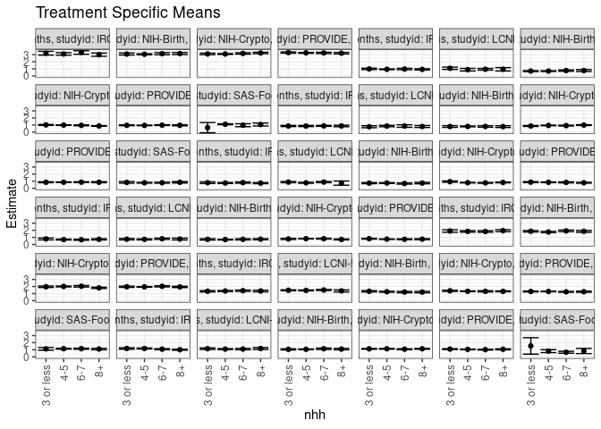

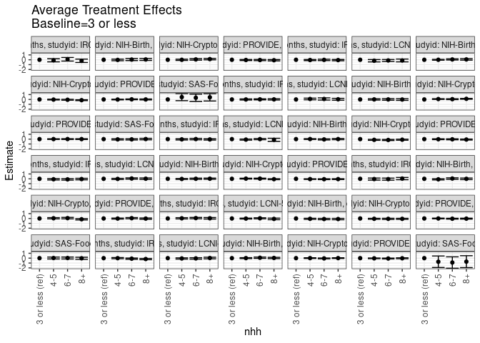

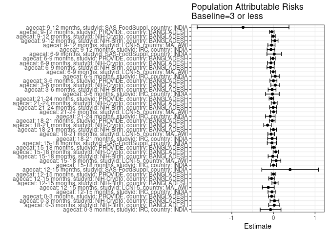

## Results Table

### Parameter: TSM

| agecat | studyid | country | intervention_level | baseline_level | estimate | ci_lower | ci_upper |
| --- | --- | --- | --- | --- | --- | --- | --- |
| 0-3 months | IRC | INDIA | 3 or less | NA | 3.2069686 | 2.9402534 | 3.4736838 |
| 0-3 months | IRC | INDIA | 4-5 | NA | 3.1014397 | 2.9262460 | 3.2766334 |
| 0-3 months | IRC | INDIA | 6-7 | NA | 3.3103536 | 3.0607490 | 3.5599583 |
| 0-3 months | IRC | INDIA | 8+ | NA | 2.9981725 | 2.7724776 | 3.2238675 |
| 0-3 months | NIH-Birth | BANGLADESH | 3 or less | NA | 3.0906403 | 2.9471453 | 3.2341352 |
| 0-3 months | NIH-Birth | BANGLADESH | 4-5 | NA | 3.0604585 | 2.9784523 | 3.1424647 |
| 0-3 months | NIH-Birth | BANGLADESH | 6-7 | NA | 3.1357017 | 2.9867678 | 3.2846355 |
| 0-3 months | NIH-Birth | BANGLADESH | 8+ | NA | 3.1575479 | 3.0173305 | 3.2977652 |
| 0-3 months | NIH-Crypto | BANGLADESH | 3 or less | NA | 3.1036724 | 2.9915374 | 3.2158074 |
| 0-3 months | NIH-Crypto | BANGLADESH | 4-5 | NA | 3.0999462 | 3.0400313 | 3.1598611 |
| 0-3 months | NIH-Crypto | BANGLADESH | 6-7 | NA | 3.1775621 | 3.0815154 | 3.2736088 |
| 0-3 months | NIH-Crypto | BANGLADESH | 8+ | NA | 3.2409247 | 3.1477423 | 3.3341071 |
| 0-3 months | PROVIDE | BANGLADESH | 3 or less | NA | 3.3021372 | 3.2154858 | 3.3887886 |
| 0-3 months | PROVIDE | BANGLADESH | 4-5 | NA | 3.2568532 | 3.2009860 | 3.3127204 |
| 0-3 months | PROVIDE | BANGLADESH | 6-7 | NA | 3.2478121 | 3.1602743 | 3.3353498 |
| 0-3 months | PROVIDE | BANGLADESH | 8+ | NA | 3.2099037 | 3.1049126 | 3.3148949 |
| 3-6 months | IRC | INDIA | 3 or less | NA | 1.9058370 | 1.7263298 | 2.0853441 |
| 3-6 months | IRC | INDIA | 4-5 | NA | 1.8521593 | 1.7468649 | 1.9574537 |
| 3-6 months | IRC | INDIA | 6-7 | NA | 1.8385357 | 1.7273837 | 1.9496876 |
| 3-6 months | IRC | INDIA | 8+ | NA | 1.9487958 | 1.8058718 | 2.0917199 |
| 3-6 months | NIH-Birth | BANGLADESH | 3 or less | NA | 1.8655469 | 1.7667494 | 1.9643444 |
| 3-6 months | NIH-Birth | BANGLADESH | 4-5 | NA | 1.7613469 | 1.6874689 | 1.8352250 |
| 3-6 months | NIH-Birth | BANGLADESH | 6-7 | NA | 1.9208138 | 1.8060987 | 2.0355289 |
| 3-6 months | NIH-Birth | BANGLADESH | 8+ | NA | 1.8611492 | 1.7328307 | 1.9894677 |
| 3-6 months | NIH-Crypto | BANGLADESH | 3 or less | NA | 1.9614900 | 1.8529308 | 2.0700492 |
| 3-6 months | NIH-Crypto | BANGLADESH | 4-5 | NA | 2.0067331 | 1.9425440 | 2.0709223 |
| 3-6 months | NIH-Crypto | BANGLADESH | 6-7 | NA | 2.0307535 | 1.9255549 | 2.1359521 |
| 3-6 months | NIH-Crypto | BANGLADESH | 8+ | NA | 1.8059548 | 1.7182135 | 1.8936960 |
| 3-6 months | PROVIDE | BANGLADESH | 3 or less | NA | 1.9656872 | 1.8728271 | 2.0585473 |
| 3-6 months | PROVIDE | BANGLADESH | 4-5 | NA | 1.9486770 | 1.9016900 | 1.9956640 |

[output cut: 138 more lines]

### Parameter: E(Y)

| agecat | studyid | country | intervention_level | baseline_level | estimate | ci_lower | ci_upper |
| --- | --- | --- | --- | --- | --- | --- | --- |
| 0-3 months | IRC | INDIA | NA | NA | 3.1382493 | 3.0275242 | 3.2489743 |
| 0-3 months | NIH-Birth | BANGLADESH | NA | NA | 3.1100116 | 3.0566021 | 3.1634210 |
| 0-3 months | NIH-Crypto | BANGLADESH | NA | NA | 3.1292449 | 3.0928504 | 3.1656393 |
| 0-3 months | PROVIDE | BANGLADESH | NA | NA | 3.2576810 | 3.2206777 | 3.2946843 |
| 3-6 months | IRC | INDIA | NA | NA | 1.8806738 | 1.8168757 | 1.9444719 |
| 3-6 months | NIH-Birth | BANGLADESH | NA | NA | 1.8326915 | 1.7846731 | 1.8807099 |
| 3-6 months | NIH-Crypto | BANGLADESH | NA | NA | 2.0057973 | 1.9693775 | 2.0422170 |
| 3-6 months | PROVIDE | BANGLADESH | NA | NA | 1.9657457 | 1.9318660 | 1.9996254 |
| 6-9 months | IRC | INDIA | NA | NA | 1.3724009 | 1.3237927 | 1.4210091 |
| 6-9 months | LCNI-5 | MALAWI | NA | NA | 1.4589363 | 1.4224162 | 1.4954563 |
| 6-9 months | NIH-Birth | BANGLADESH | NA | NA | 1.2555950 | 1.2150667 | 1.2961234 |
| 6-9 months | NIH-Crypto | BANGLADESH | NA | NA | 1.3282695 | 1.2988292 | 1.3577098 |
| 6-9 months | PROVIDE | BANGLADESH | NA | NA | 1.2824185 | 1.2571827 | 1.3076542 |
| 6-9 months | SAS-FoodSuppl | INDIA | NA | NA | 1.1426155 | 1.1021386 | 1.1830923 |
| 9-12 months | IRC | INDIA | NA | NA | 1.1234734 | 1.0841051 | 1.1628417 |
| 9-12 months | LCNI-5 | MALAWI | NA | NA | 1.1007887 | 1.0539615 | 1.1476158 |
| 9-12 months | NIH-Birth | BANGLADESH | NA | NA | 1.0885809 | 1.0534446 | 1.1237171 |
| 9-12 months | NIH-Crypto | BANGLADESH | NA | NA | 1.1234745 | 1.0972274 | 1.1497215 |
| 9-12 months | PROVIDE | BANGLADESH | NA | NA | 1.0499750 | 1.0230130 | 1.0769370 |
| 9-12 months | SAS-FoodSuppl | INDIA | NA | NA | 0.8106649 | 0.6745544 | 0.9467754 |
| 12-15 months | IRC | INDIA | NA | NA | 0.9553539 | 0.9137750 | 0.9969329 |
| 12-15 months | LCNI-5 | MALAWI | NA | NA | 0.9578403 | 0.8612449 | 1.0544357 |
| 12-15 months | NIH-Birth | BANGLADESH | NA | NA | 0.7241623 | 0.6797013 | 0.7686233 |
| 12-15 months | NIH-Crypto | BANGLADESH | NA | NA | 0.9711395 | 0.9465805 | 0.9956985 |
| 12-15 months | PROVIDE | BANGLADESH | NA | NA | 0.9597501 | 0.9335899 | 0.9859102 |
| 12-15 months | SAS-FoodSuppl | INDIA | NA | NA | 1.0267825 | 0.9374856 | 1.1160794 |
| 15-18 months | IRC | INDIA | NA | NA | 0.8591216 | 0.8197594 | 0.8984837 |
| 15-18 months | LCNI-5 | MALAWI | NA | NA | 0.8227868 | 0.7513696 | 0.8942040 |
| 15-18 months | NIH-Birth | BANGLADESH | NA | NA | 0.7727719 | 0.7325606 | 0.8129832 |
| 15-18 months | NIH-Crypto | BANGLADESH | NA | NA | 0.9177168 | 0.8947657 | 0.9406678 |
| 15-18 months | PROVIDE | BANGLADESH | NA | NA | 0.8560998 | 0.8320145 | 0.8801852 |
| 15-18 months | SAS-FoodSuppl | INDIA | NA | NA | 0.7947861 | 0.7590601 | 0.8305122 |
| 18-21 months | IRC | INDIA | NA | NA | 0.7598022 | 0.7214752 | 0.7981291 |
| 18-21 months | LCNI-5 | MALAWI | NA | NA | 0.8198090 | 0.7732927 | 0.8663254 |
| 18-21 months | NIH-Birth | BANGLADESH | NA | NA | 0.7291468 | 0.6930874 | 0.7652062 |
| 18-21 months | NIH-Crypto | BANGLADESH | NA | NA | 0.7977755 | 0.7744353 | 0.8211158 |
| 18-21 months | PROVIDE | BANGLADESH | NA | NA | 0.8393377 | 0.8153485 | 0.8633269 |
| 21-24 months | IRC | INDIA | NA | NA | 0.7084129 | 0.6674749 | 0.7493508 |
| 21-24 months | LCNI-5 | MALAWI | NA | NA | 0.7505036 | 0.7048983 | 0.7961088 |
| 21-24 months | NIH-Birth | BANGLADESH | NA | NA | 0.7172178 | 0.6817161 | 0.7527194 |
| 21-24 months | NIH-Crypto | BANGLADESH | NA | NA | 0.7993353 | 0.7748026 | 0.8238681 |
| 21-24 months | PROVIDE | BANGLADESH | NA | NA | 0.7631391 | 0.7377453 | 0.7885328 |

### Parameter: ATE

| agecat | studyid | country | intervention_level | baseline_level | estimate | ci_lower | ci_upper |
| --- | --- | --- | --- | --- | --- | --- | --- |
| 0-3 months | IRC | INDIA | 3 or less | 3 or less | 0.0000000 | 0.0000000 | 0.0000000 |
| 0-3 months | IRC | INDIA | 4-5 | 3 or less | -0.1055289 | -0.4237858 | 0.2127280 |
| 0-3 months | IRC | INDIA | 6-7 | 3 or less | 0.1033850 | -0.2619575 | 0.4687275 |
| 0-3 months | IRC | INDIA | 8+ | 3 or less | -0.2087961 | -0.5583126 | 0.1407205 |
| 0-3 months | NIH-Birth | BANGLADESH | 3 or less | 3 or less | 0.0000000 | 0.0000000 | 0.0000000 |
| 0-3 months | NIH-Birth | BANGLADESH | 4-5 | 3 or less | -0.0301818 | -0.1951311 | 0.1347676 |
| 0-3 months | NIH-Birth | BANGLADESH | 6-7 | 3 or less | 0.0450614 | -0.1615631 | 0.2516858 |
| 0-3 months | NIH-Birth | BANGLADESH | 8+ | 3 or less | 0.0669076 | -0.1335845 | 0.2673997 |
| 0-3 months | NIH-Crypto | BANGLADESH | 3 or less | 3 or less | 0.0000000 | 0.0000000 | 0.0000000 |
| 0-3 months | NIH-Crypto | BANGLADESH | 4-5 | 3 or less | -0.0037262 | -0.1306173 | 0.1231649 |
| 0-3 months | NIH-Crypto | BANGLADESH | 6-7 | 3 or less | 0.0738897 | -0.0736884 | 0.2214678 |
| 0-3 months | NIH-Crypto | BANGLADESH | 8+ | 3 or less | 0.1372523 | -0.0085679 | 0.2830725 |
| 0-3 months | PROVIDE | BANGLADESH | 3 or less | 3 or less | 0.0000000 | 0.0000000 | 0.0000000 |
| 0-3 months | PROVIDE | BANGLADESH | 4-5 | 3 or less | -0.0452840 | -0.1488888 | 0.0583209 |
| 0-3 months | PROVIDE | BANGLADESH | 6-7 | 3 or less | -0.0543251 | -0.1778986 | 0.0692483 |
| 0-3 months | PROVIDE | BANGLADESH | 8+ | 3 or less | -0.0922335 | -0.2283312 | 0.0438643 |
| 3-6 months | IRC | INDIA | 3 or less | 3 or less | 0.0000000 | 0.0000000 | 0.0000000 |
| 3-6 months | IRC | INDIA | 4-5 | 3 or less | -0.0536777 | -0.2621177 | 0.1547624 |
| 3-6 months | IRC | INDIA | 6-7 | 3 or less | -0.0673013 | -0.2786526 | 0.1440500 |
| 3-6 months | IRC | INDIA | 8+ | 3 or less | 0.0429589 | -0.1864301 | 0.2723479 |
| 3-6 months | NIH-Birth | BANGLADESH | 3 or less | 3 or less | 0.0000000 | 0.0000000 | 0.0000000 |
| 3-6 months | NIH-Birth | BANGLADESH | 4-5 | 3 or less | -0.1042000 | -0.2275443 | 0.0191443 |
| 3-6 months | NIH-Birth | BANGLADESH | 6-7 | 3 or less | 0.0552669 | -0.0961219 | 0.2066557 |
| 3-6 months | NIH-Birth | BANGLADESH | 8+ | 3 or less | -0.0043977 | -0.1664114 | 0.1576160 |
| 3-6 months | NIH-Crypto | BANGLADESH | 3 or less | 3 or less | 0.0000000 | 0.0000000 | 0.0000000 |
| 3-6 months | NIH-Crypto | BANGLADESH | 4-5 | 3 or less | 0.0452431 | -0.0811592 | 0.1716454 |
| 3-6 months | NIH-Crypto | BANGLADESH | 6-7 | 3 or less | 0.0692635 | -0.0819959 | 0.2205228 |
| 3-6 months | NIH-Crypto | BANGLADESH | 8+ | 3 or less | -0.1555353 | -0.2955013 | -0.0155693 |
| 3-6 months | PROVIDE | BANGLADESH | 3 or less | 3 or less | 0.0000000 | 0.0000000 | 0.0000000 |
| 3-6 months | PROVIDE | BANGLADESH | 4-5 | 3 or less | -0.0170103 | -0.1211922 | 0.0871717 |

[output cut: 138 more lines]

### Parameter: PAR

| agecat | studyid | country | intervention_level | baseline_level | estimate | ci_lower | ci_upper |
| --- | --- | --- | --- | --- | --- | --- | --- |
| 0-3 months | IRC | INDIA | 3 or less | NA | -0.0687194 | -0.3185389 | 0.1811002 |
| 0-3 months | NIH-Birth | BANGLADESH | 3 or less | NA | 0.0193713 | -0.1134601 | 0.1522027 |
| 0-3 months | NIH-Crypto | BANGLADESH | 3 or less | NA | 0.0255725 | -0.0800045 | 0.1311494 |
| 0-3 months | PROVIDE | BANGLADESH | 3 or less | NA | -0.0444562 | -0.1229134 | 0.0340011 |
| 3-6 months | IRC | INDIA | 3 or less | NA | -0.0251631 | -0.1911710 | 0.1408448 |
| 3-6 months | NIH-Birth | BANGLADESH | 3 or less | NA | -0.0328554 | -0.1270803 | 0.0613695 |
| 3-6 months | NIH-Crypto | BANGLADESH | 3 or less | NA | 0.0443072 | -0.0613912 | 0.1500057 |
| 3-6 months | PROVIDE | BANGLADESH | 3 or less | NA | 0.0000585 | -0.0839841 | 0.0841011 |
| 6-9 months | IRC | INDIA | 3 or less | NA | 0.0436759 | -0.0531345 | 0.1404863 |
| 6-9 months | LCNI-5 | MALAWI | 3 or less | NA | -0.0060975 | -0.0687005 | 0.0565055 |
| 6-9 months | NIH-Birth | BANGLADESH | 3 or less | NA | -0.0689434 | -0.1551064 | 0.0172195 |
| 6-9 months | NIH-Crypto | BANGLADESH | 3 or less | NA | -0.0587336 | -0.1429063 | 0.0254392 |
| 6-9 months | PROVIDE | BANGLADESH | 3 or less | NA | -0.0128580 | -0.0690751 | 0.0433590 |
| 6-9 months | SAS-FoodSuppl | INDIA | 3 or less | NA | 0.0194584 | -0.1559086 | 0.1948255 |
| 9-12 months | IRC | INDIA | 3 or less | NA | -0.0588577 | -0.1509194 | 0.0332040 |
| 9-12 months | LCNI-5 | MALAWI | 3 or less | NA | -0.0469128 | -0.1330134 | 0.0391878 |
| 9-12 months | NIH-Birth | BANGLADESH | 3 or less | NA | 0.0345197 | -0.0415984 | 0.1106378 |
| 9-12 months | NIH-Crypto | BANGLADESH | 3 or less | NA | -0.0035515 | -0.0513608 | 0.0442578 |
| 9-12 months | PROVIDE | BANGLADESH | 3 or less | NA | -0.0398272 | -0.0955144 | 0.0158600 |
| 9-12 months | SAS-FoodSuppl | INDIA | 3 or less | NA | -0.7293242 | -1.8328077 | 0.3741592 |
| 12-15 months | IRC | INDIA | 3 or less | NA | -0.0359036 | -0.1297522 | 0.0579450 |
| 12-15 months | LCNI-5 | MALAWI | 3 or less | NA | -0.1230540 | -0.2652997 | 0.0191916 |
| 12-15 months | NIH-Birth | BANGLADESH | 3 or less | NA | 0.0379434 | -0.0353928 | 0.1112796 |
| 12-15 months | NIH-Crypto | BANGLADESH | 3 or less | NA | -0.0448519 | -0.1109546 | 0.0212508 |
| 12-15 months | PROVIDE | BANGLADESH | 3 or less | NA | 0.0020038 | -0.0541642 | 0.0581719 |
| 12-15 months | SAS-FoodSuppl | INDIA | 3 or less | NA | 0.4002406 | -0.2796326 | 1.0801138 |
| 15-18 months | IRC | INDIA | 3 or less | NA | -0.0001736 | -0.0751915 | 0.0748442 |
| 15-18 months | LCNI-5 | MALAWI | 3 or less | NA | 0.0650540 | -0.0474351 | 0.1775432 |
| 15-18 months | NIH-Birth | BANGLADESH | 3 or less | NA | -0.0162476 | -0.1269796 | 0.0944845 |
| 15-18 months | NIH-Crypto | BANGLADESH | 3 or less | NA | 0.0559254 | -0.0073868 | 0.1192376 |
| 15-18 months | PROVIDE | BANGLADESH | 3 or less | NA | 0.0041351 | -0.0512490 | 0.0595192 |
| 15-18 months | SAS-FoodSuppl | INDIA | 3 or less | NA | -0.0371521 | -0.1486252 | 0.0743210 |
| 18-21 months | IRC | INDIA | 3 or less | NA | -0.0329376 | -0.1376881 | 0.0718128 |
| 18-21 months | LCNI-5 | MALAWI | 3 or less | NA | -0.0548763 | -0.1336840 | 0.0239314 |
| 18-21 months | NIH-Birth | BANGLADESH | 3 or less | NA | 0.0001163 | -0.0729770 | 0.0732097 |
| 18-21 months | NIH-Crypto | BANGLADESH | 3 or less | NA | -0.1416145 | -0.2327801 | -0.0504488 |
| 18-21 months | PROVIDE | BANGLADESH | 3 or less | NA | -0.0282807 | -0.0963333 | 0.0397720 |
| 21-24 months | IRC | INDIA | 3 or less | NA | -0.0760134 | -0.1920695 | 0.0400428 |
| 21-24 months | LCNI-5 | MALAWI | 3 or less | NA | 0.0034308 | -0.0725622 | 0.0794237 |
| 21-24 months | NIH-Birth | BANGLADESH | 3 or less | NA | -0.0062391 | -0.0896570 | 0.0771788 |
| 21-24 months | NIH-Crypto | BANGLADESH | 3 or less | NA | 0.0181068 | -0.0538693 | 0.0900830 |
| 21-24 months | PROVIDE | BANGLADESH | 3 or less | NA | -0.0492886 | -0.1036121 | 0.0050350 |